# Wikipedia muudatussõjad

Krister Jaanhold

# 1 Sissejuhatus

Muudatussõda *(edit-war)* on nähtus, mille puhul artikli muutjad ei ole ühisel arusaamal artikli sisulistes küsimustes ning muudavad artiklit kordamööda, omale sobival moel. Näiteks on Nikola Tesla artiklit muudetud korduvalt lühikese aja jooksul, sest on erinevaid allikaid tema rahvuse kohta - näiteks on horvaadid ja austerlased tihti muutnud artiklit just nende rahvust soosivalt. Ühelt poolt oleks huvitav näha, millised artiklid need on ning teha nende põhjal lihtsamat statistikat, ent teisalt võib asjal olla ka meelelahutuslik külg - näiteks kui mõni kuulsus saab ebapopulaarse teoga hakkama, siis üsna tihti muudetakse sellest tingitult tema Wikipedia artiklit päris lõbusal moel. Käesoleva artikli eesmärk on juhendamata õppe meetodeid ning veebist kraabitud andmeid kasutades tuvastada selliseid artikleid, mille puhul võib tegemist olla muudatussõjaga. Uurimisprobleemi muudab keeruliseks märgendatu andmete puudumine, st ei ole teada millised reaalsuses on need artiklid, kus on muudatussõda toimunud, sh kuidas eristada muudatussõda normaalsetest ent muudatustest. Lisaks sellele muudab ülesande keeruliseks andmete rohkus.

# 2 Andmestik ja metoodika

Muudatussõdade tuvastamiseks saab kasutada erinevatest allikatest pärinevaid andmeid, olgu selleks siis WikiStats kataloog[^1], andmebaasi koopiad[^2] või andmete kraapimine otse Wikipedia lehtedelt kasutadeks MediaWiki API-d [^3]. Esimese kahe variandi puhul on tegu väga suurte XML formaadis failidega, mida R-is töödelda ei ole võimalik ega mõistlik. Selleks, et seada piiranguid nii andmete mahule kui ka sisule, tuleks need veebist ise kraapida. Ühe olulise kitsendusena on vaatluse alla on võetud kõik ingliskeelsed ning Wikipedia klassifikatsiooni järgi elujõulised (*vital*) lehed. Lehed on jagatud 11 järgnevasse kategooriasse - inimesed, ajalugu, geograafia, kunstid, filosoofia ja religioon, igapäevaelu, ühiskond ja sotsiaalteadused, bioloogia ja terviseteadused, füüsikateadused, tehnoloogia ning matemaatika. Järgmisena kitsendusena on vaatluse alla võetud juhuslikkuse alusel vaid 0.5% kõikidest elujõulistest artiklitest. Iga artikli kohta kraabitakse kogu tema muudatusajalugu ning lisaks sellele ka muutja nimi või IP (juhul kui pole kasutajat), muudatuse ajatempel (*timestamp*), artikli nimi, artikli kategooria, tõeväärtus (kas muudatuses oli ka kommentaar) ning kommentaar ise. Nende põhjal arvutatakse iga artikli iga muudatuse kohta järgnevad mõõdikud - möödunud aeg (sekundites) eelmisest muudatusest ning kui paljud inimesed olid selleks hetkeks artiklit muutnud.

Selleks, et võimalikke muudatussõdasid tuvastada, uurime lähemalt nende kahe tunnuse jaotust iga artikli lõikes. Hüpoteetiliselt huvitavad meid need artiklid, mille puhul on palju muudatusi tehtud lühikese ajavahemiku jooksul väikse arvu kasutajate poolt. Anomaaliate leidmiseks arvutame iga artikli mõlema tunnuse põhjal protsentiilid (kokku 200 tunnust), leiame kommentaariga muudatuste osakaalu ning treenime selle põhjal juhendamata tehisnärvivõrgu *autoencoder*, mis teoreetiliselt suudab tuvastada kõrvalekaldeid normaalsest käitumisest. Autoencoderi struktuur on esitatud järgneval joonisel ning selle tööpõhimõte on lihtne - igas peidetud kihis püütakse sisendtunnuseid kirjeldada vähemate tunnustega (*encode*) ning lõpuks üritatakse rekonstrueerida (*decode*) algsed tunnused kasutades kompresseeritud, st väiksema dimensionaalsusega andmeid. Juhul kui tegu on anomaaliaga (st sarnaseid treeningnäidiseid vähe), ei suuda mudel algandmeid täiuslikult rekonstrueerida ja teeb vigu. Vigade mõõtmiseks kasutame keskmist veamäära (MSE), mille alusel anomaaliad ka järjestame.

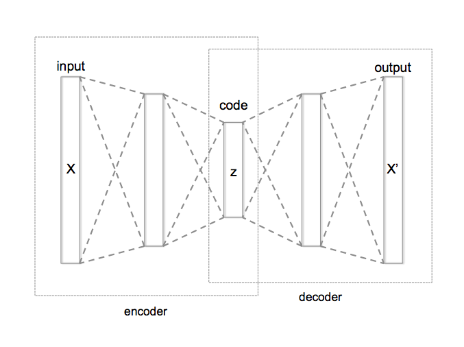

Viimaks visualiseerime mudeli jaoks anomaaliana tunduvate artiklite muudatuste ajajoont. Arvestades, et anomaaliaid võib olla erinevaid - nii selliseid, kus artiklit on muudetud võrdlemisi vähe ja harva kui ka neid, mida on vastupidiselt muudetud tihti ja väikese aja jooksul, siis tuvastame visuaalselt selle, kas tegu võis olla muudatussõjaga või mõnda muud tüüpi anomaaliaga.

Kokkuvõtvalt toimub uurimisprobleemi lahendamine järgmistes etappides:

1. andmete kraapimine veebist,
2. kirjeldavate tunnuste tuletamine ning arvutamine,
3. tunnuste agregeerimine,
4. juhendamata õppe mudeli sobitamine ning anomaaliate leidmine,
5. anomaaliate visualiseerimine ning verifitseerimine.

# 3 Muudatussõdade tuvastamine

Selleks, et tuhandete artiklite seast tuvastada kõrvalekaldeid, treeniti juhendamata närvivõrk järgnevate parameetritega:

- 500 epohhi,
- aktiveerimisfunktsioon: hüperboolne tangents,
- 3 varjatud kihiga, kus oli vastavalt 128, 64, 128 neuronit.

Treenitud mudeli põhjal leiti paljude artiklite seast võimalikud anomaaliad ning visualiseeriti neid. Järgneval joonisel on kujutatud konkreetse artikli kõik muudatused horisontaalteljel ning vertikaaltelg näitab, mitu sekundit oli möödunud eelmisest muudatusest. Joonise põhjal saab kinnitust, et kõrvalekalde põhjus ei pruugi olla vaid muudatussõda vaid ka vastupidine - antud artiklit on muudetud harva ning üldiselt jääb muudatuste vahele pikk aeg.

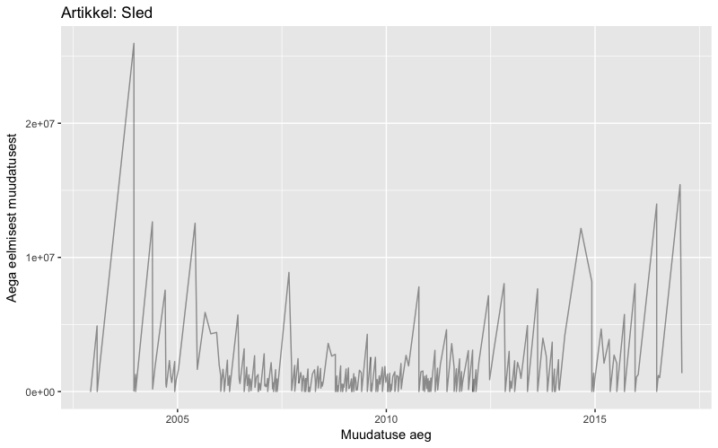

See-eest tuvastasime ka meid huvitavaid anomaaliaid, nagu näiteks artikkel Johannes IV-st - järgneval joonisel on näha, et ajavahemikus 2006-2008 on artiklit muudetud väga sageli ning tihti lühikese aja jooksul. Tulenevalt sellest, et tegu on siiski üsna pika ajavahemikuga, ei saa üheselt väita et tegu oleks olnud muudatussõjaga ning sellest tulenevalt vaatame järgmisena lähemalt vaid ajavahemikku pärast 2016. aastat (kaasaarvatud).

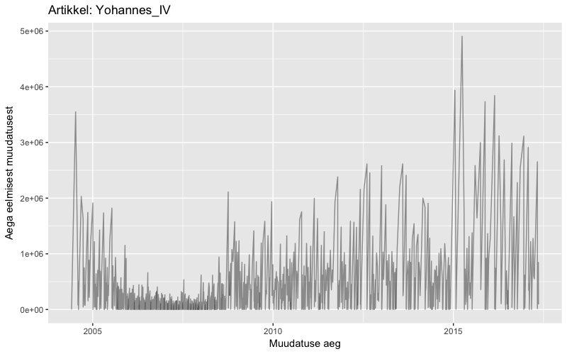

Järgnevalt on tunnused ümber arvutatud võttes arvesse vaid muudatusi pärast 2016. aastat (kaasaarvatud) ning treenitud uus mudel. Sarnaselt eelmisele korrale tuvastas mudel kaht tüüpi anomaaliaid - neid, kus on muudatusi tehtud harva ja pika aja tagant ning ka neid, kus on mingil võrdlemisi lühikesel ajavahemikul tehtud palju muudatusi. Järgneval joonisel on näha, et 2016 aasta lõpus on näiteks artiklit “Decibel”[^4] muudetud lühikese ajavahemiku jooksul võrdlemisi palju. Vaatamata sellele on muudatuse ajaloost näha, et peamised muudatused on olnud seotud lehe vormindamisega.

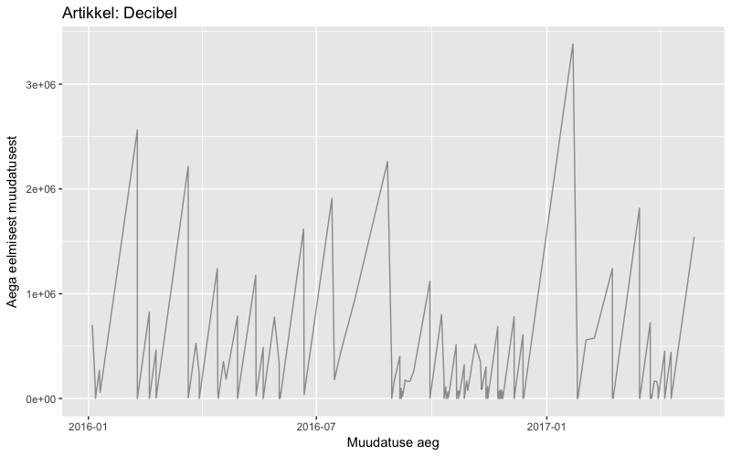

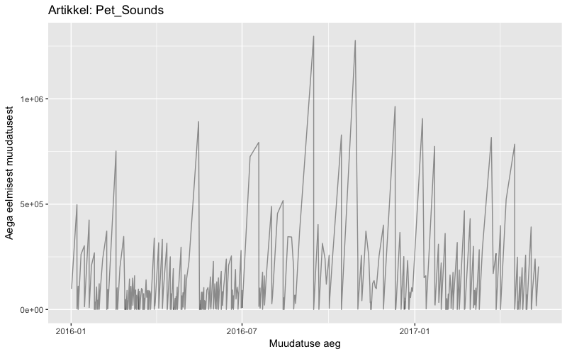

Järgneval joonisel on esitatud rekonstrueerimisel tehtud vigade jaotus mõlema mudeli puhul.

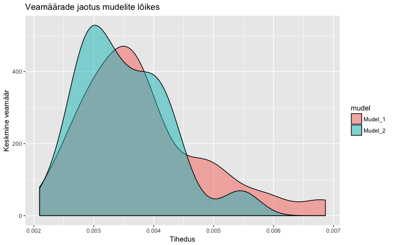

Esimene mudel on treenitud võttes arvesse kogu muudatusajalugu ning teine mudel on treenitud vaid pärast 2016. aastat toimunud muudatuste põhjal. Nähtub, et mõlema mudeli puhul on jaotusel saba kõrgemate veamäärade juures, mis viitab keskmisest käitumisest kõrvalekaldele ehk anomaaliatele.

# 4 Kokkuvõte

Muudatussõdade tuvastamine on huvitav nii praktilisest kui ka meelelahutuslikust seisukohast. Paraku on muudatussõdade tuvastamine märgendatud andmete puudumisel keeruline. Käesolevas artiklis vaadeldi lähemalt juhendamata õppe meetodi *autoencoder* abil muudatussõdade tuvastamist. Mudel suutis tõepoolest leida anomaaliaid, st kõrvalekaldeid normaalsest muudatusajaloost, kuid paraku ei inditseerinud see alati muudatussõda. Sellest tulenevalt oli oluline muudatussõdade verifitseerimiseks visualiseerida muudatuste ajajoont. Mudeli võimalikult efektiivseks rakendamiseks tuleks kasutada nii rohkemaid tunnuseid (näiteks muudatuse maht või muutva kasutaja vanus) kui ka suuremat andmehulka (mitte juhuslikku alamhulka) selleks, et suuta ilma illustratsioone kasutamata tuvastada potentsiaalseid muudatussõdasid.

[^1]: https://dumps.wikimedia.org/other/pagecounts-ez/wikistats/
[^2]: https://en.wikipedia.org/wiki/Wikipedia:Database_download
[^3]: https://www.mediawiki.org/wiki/API:Main_page
[^4]: https://en.wikipedia.org/wiki/Decibel